# Random Forest sur des données d’assurance

# 1. Objectif

On illustre la méthode **Random Forest** (forest aléatoire) appliquée à un problème de **régression** sur des données d’assurance médicale. Nous :

1. construisons une forêt sur la variable cible `PremiumPrice` ;
2. explorons les attributs de l’objet `randomForest` ;
3. faisons du **tuning** des hyperparamètres `mtry` et `maxnodes` ;
4. comparons RF, CART et GLM via une validation croisée 10-plis.

# 2. Librairies et chargement des données

```r
library(rpart)
library(randomForest)
library(caret)
library(ggplot2)
library(dplyr)
library(tidyr)
library(readr)
```

Les données `Medicalpremium.csv` sont séparées par `;` et contiennent la prime `PremiumPrice` (colonne 11) ainsi que les facteurs de risque.

```r
db <- read_delim("Medicalpremium.csv",
                             delim = ";", escape_double = FALSE, trim_ws = TRUE)
head(db)
```

```
## # A tibble: 6 × 11
##     Age Diabetes BloodPressureProblems AnyTransplants AnyChronicDiseases Height
##   <dbl>    <dbl>                 <dbl>          <dbl>              <dbl>  <dbl>
## 1    45        0                     0              0                  0    155
## 2    60        1                     0              0                  0    180
## 3    36        1                     1              0                  0    158
## 4    52        1                     1              0                  1    183
## 5    38        0                     0              0                  1    166
## 6    30        0                     0              0                  0    160
## # ℹ 5 more variables: Weight <dbl>, KnownAllergies <dbl>,
## #   HistoryOfCancerInFamily <dbl>, NumberOfMajorSurgeries <dbl>,
## #   PremiumPrice <dbl>
```

```r
str(db)
```

```
## spc_tbl_ [986 × 11] (S3: spec_tbl_df/tbl_df/tbl/data.frame)
##  $ Age                    : num [1:986] 45 60 36 52 38 30 33 23 48 38 ...
##  $ Diabetes               : num [1:986] 0 1 1 1 0 0 0 0 1 0 ...
##  $ BloodPressureProblems  : num [1:986] 0 0 1 1 0 0 0 0 0 0 ...
##  $ AnyTransplants         : num [1:986] 0 0 0 0 0 0 0 0 0 0 ...
##  $ AnyChronicDiseases     : num [1:986] 0 0 0 1 1 0 0 0 0 0 ...
##  $ Height                 : num [1:986] 155 180 158 183 166 160 150 181 169 182 ...
##  $ Weight                 : num [1:986] 57 73 59 93 88 69 54 79 74 93 ...
##  $ KnownAllergies         : num [1:986] 0 0 0 0 0 1 0 1 1 0 ...
##  $ HistoryOfCancerInFamily: num [1:986] 0 0 0 0 0 0 0 0 0 0 ...
##  $ NumberOfMajorSurgeries : num [1:986] 0 0 1 2 1 1 0 0 0 0 ...
##  $ PremiumPrice           : num [1:986] 25000 29000 23000 28000 23000 23000 21000 15000 23000 23000 ...
##  - attr(*, "spec")=
##   .. cols(
##   ..   Age = col_double(),
##   ..   Diabetes = col_double(),
##   ..   BloodPressureProblems = col_double(),
##   ..   AnyTransplants = col_double(),
##   ..   AnyChronicDiseases = col_double(),
##   ..   Height = col_double(),
##   ..   Weight = col_double(),
##   ..   KnownAllergies = col_double(),
##   ..   HistoryOfCancerInFamily = col_double(),
##   ..   NumberOfMajorSurgeries = col_double(),
##   ..   PremiumPrice = col_double()
##   .. )
##  - attr(*, "problems")=<externalptr>
```

La variable cible est `PremiumPrice` ; les prédicteurs sont les `ncol(db) - 1` colonnes restantes.

# 3. Première forêt aléatoire

## 3.1. Construction

Nous construisons une forêt de `ntree = 500` arbres. Le paramètre `mtry` est fixé à $\sqrt{p-1}$ (règle usuelle pour la régression), et `nodesize = 1` autorise des feuilles d’une seule observation (arbres pleinement croissés).

```r
rf <- randomForest(data = db,
                   PremiumPrice ~ .,
                   ntree  = 500,
                   mtry   = sqrt(ncol(db) - 1),
                   nodesize = 1,
                   maxnodes = NULL)
```

## 3.2. Attributs de l’objet `randomForest`

| Attribut | Signification |
| --- | --- |
| `rf$predicted` | Valeurs prédites par la forêt pour chaque individu |
| `rf$mse` | Erreur quadratique **OOB** (out-of-bag) par nombre d’arbres |
| `rf$oob.times` | Nombre de fois où chaque observation est OOB sur l’ensemble des arbres |
| `rf$importance` | Importance des variables (décroissance d’hétérogénéité) |
| `rf$forest$ndbigtree` | Nombre de nœuds par arbre |

On vérifie la propriété théorique du bootstrap : une observation n’est tirée que avec probabilité $1 - 1/n$ à chaque tirage, donc elle est OOB environ $e^{-1} \times \text{ntree}$ fois.

```r
mean(rf$oob.times)
```

```
## [1] 184.0913
```

```r
exp(-1) * 500   # valeur théorique
```

```
## [1] 183.9397
```

## 3.3. Erreur OOB en fonction du nombre d’arbres

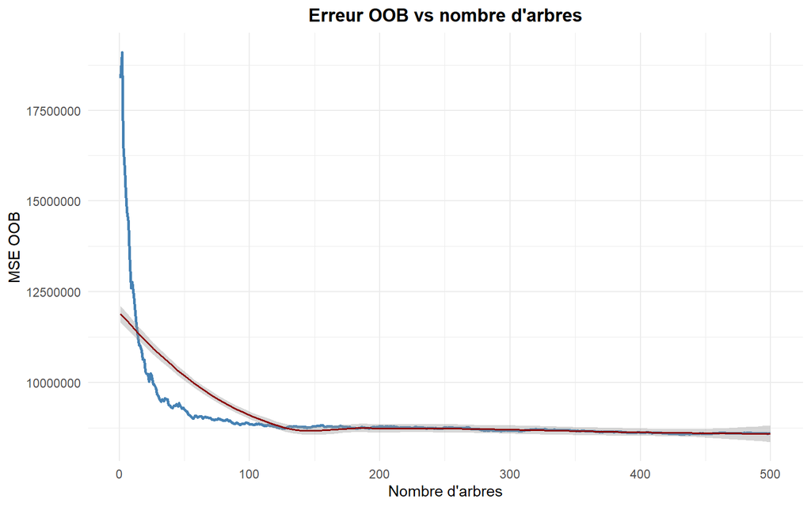

Erreur OOB en fonction du nombre d’arbres.

```r
oob_df <- data.frame(
  ntree = seq_along(rf$mse),
  mse   = rf$mse
)

ggplot(oob_df, aes(x = ntree, y = mse)) +
  geom_line(color = "steelblue", linewidth = 0.9) +
  geom_smooth(method = "loess", se = TRUE,
              color = "darkred", linewidth = 0.6) +
  labs(title = "Erreur OOB vs nombre d'arbres",
       x = "Nombre d'arbres",
       y = "MSE OOB") +
  theme_minimal() +
  theme(plot.title = element_text(hjust = 0.5, face = "bold"))
```

La courbe décroît puis se stabilise : au-delà d’environ 200–300 arbres, ajouter des arbres n’améliore plus l’erreur OOB.

## 3.4. Importance des variables

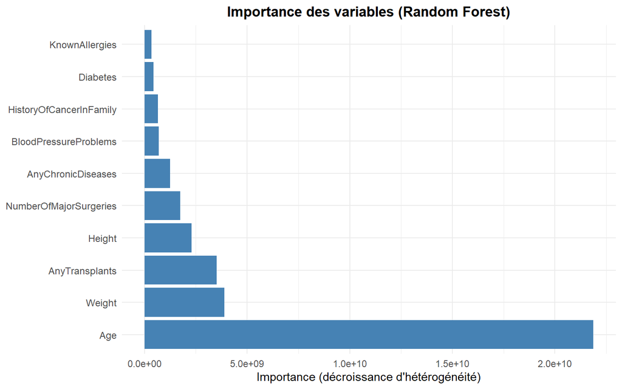

Importance des variables de risque.

```r
imp_df <- data.frame(
  Variable   = rownames(rf$importance),
  Importance = rf$importance[, 1]
) %>%
  arrange(desc(Importance)) %>%
  mutate(Variable = factor(Variable, levels = Variable))

ggplot(imp_df, aes(x = Importance, y = Variable)) +
  geom_col(fill = "steelblue") +
  labs(title = "Importance des variables (Random Forest)",
       x = "Importance (décroissance d'hétérogénéité)",
       y = NULL) +
  theme_minimal() +
  theme(plot.title = element_text(hjust = 0.5, face = "bold"),
        axis.text.y = element_text(size = 9))
```

# 4. Tuning des hyperparamètres

## 4.1. Effet de `mtry`

On fait varier le nombre de variables tirées à chaque nœud (`mtry`) et on mesure l’erreur OOB finale.

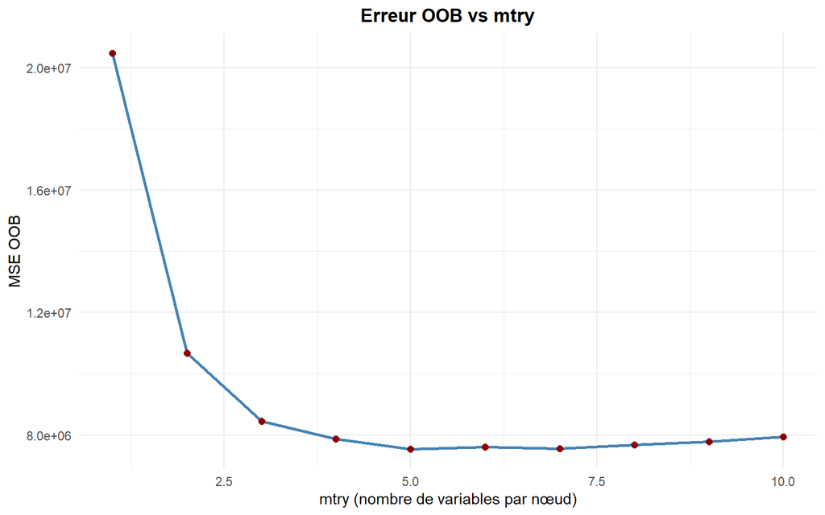

Erreur OOB en fonction de mtry.

```r
errorVar <- sapply(1:(ncol(db) - 1), function(ii) {
  tail(randomForest(data = db, PremiumPrice ~ .,
                    maxnodes = NULL, mtry = ii, ntree = 500)$mse, 1)
})

mtry_df <- data.frame(
  mtry = 1:(ncol(db) - 1),
  mse  = errorVar
)

ggplot(mtry_df, aes(x = mtry, y = mse)) +
  geom_line(color = "steelblue", linewidth = 0.9) +
  geom_point(color = "darkred", size = 2) +
  labs(title = "Erreur OOB vs mtry",
       x = "mtry (nombre de variables par nœud)",
       y = "MSE OOB") +
  theme_minimal() +
  theme(plot.title = element_text(hjust = 0.5, face = "bold"))
```

> **Lecture** : l’erreur est minimale autour de `mtry = 6` ; au-delà, les arbres se corrélatent trop et la variance augmente.

## 4.2. Effet de la profondeur (`maxnodes`)

On fixe `mtry = 6` et on varie le nombre maximal de nœuds par arbre. Chaque configuration est évaluée 5 fois pour lisser le bruit.

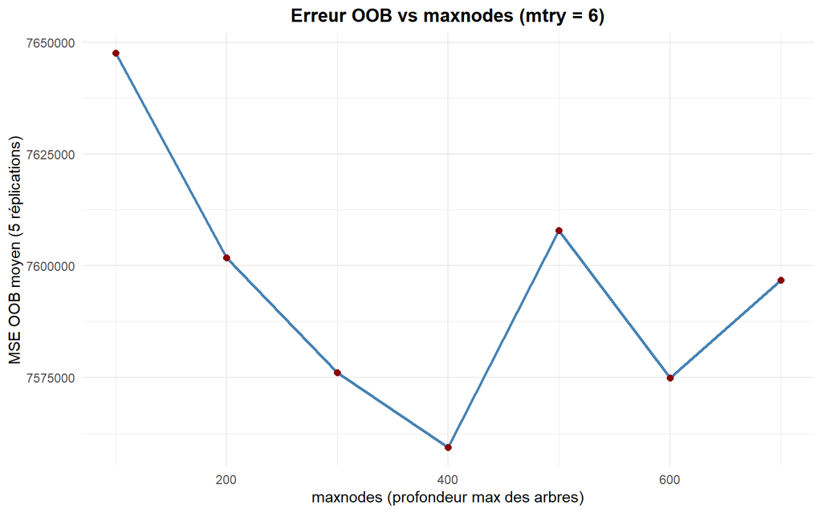

Erreur OOB en fonction de maxnodes (mtry = 6).

```r
errorNod <- sapply((1:7) * 100, function(ii) {
  errs <- replicate(5, {
    tail(randomForest(data = db, PremiumPrice ~ .,
                      maxnodes = ii, mtry = 6, ntree = 500)$mse, 1)
  })
  mean(errs)
})

nodes_df <- data.frame(
  maxnodes = (1:7) * 100,
  mse      = errorNod
)

ggplot(nodes_df, aes(x = maxnodes, y = mse)) +
  geom_line(color = "steelblue", linewidth = 0.9) +
  geom_point(color = "darkred", size = 2) +
  labs(title = "Erreur OOB vs maxnodes (mtry = 6)",
       x = "maxnodes (profondeur max des arbres)",
       y = "MSE OOB moyen (5 réplications)") +
  theme_minimal() +
  theme(plot.title = element_text(hjust = 0.5, face = "bold"))
```

> **Lecture** : peu de changement au-delà de 300 nœuds ; les arbres sont suffisamment profonds pour capturer la structure.

## 4.3. Grille conjointe `mtry` × `maxnodes`

On explore une grille de valeurs et on trace la carte de chaleur des erreurs.

```r
params <- expand.grid(nbVar  = 3:8,
                      nbNode = (2:8) * 100)

t1 <- Sys.time()
params$error <- sapply(1:nrow(params), function(ii) {
  errs <- replicate(5, {
    tail(randomForest(data = db, PremiumPrice ~ .,
                      maxnodes = params$nbNode[ii],
                      mtry     = params$nbVar[ii],
                      ntree    = 500)$mse, 1)
  })
  mean(errs)
})
t2 <- Sys.time()
cat("Temps d'exécution de la grille :", as.numeric(t2 - t1, units = "mins"), "min\n")
```

```
## Temps d'exécution de la grille : 2.583054 min
```

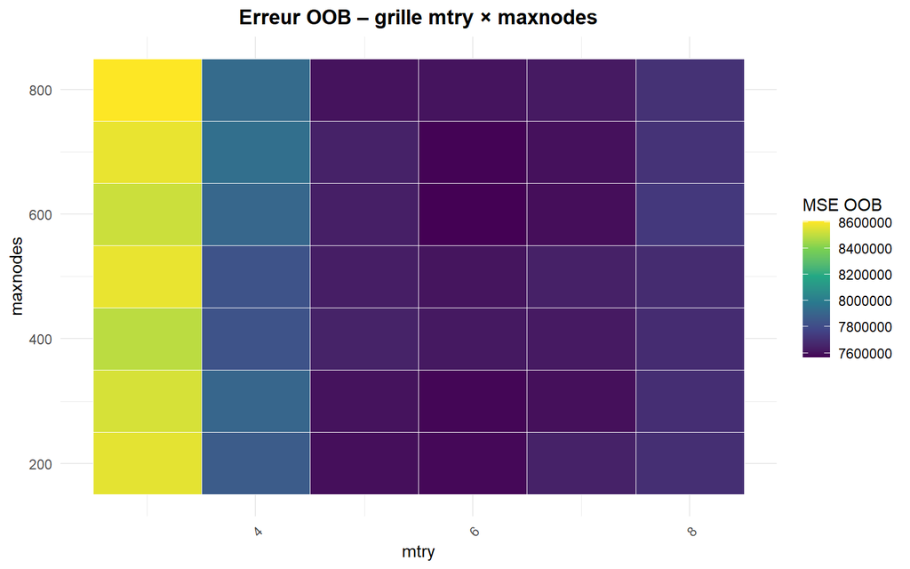

Heatmap de l’erreur OOB sur la grille mtry × maxnodes.

```r
ggplot(params, aes(x = nbVar, y = nbNode, fill = error)) +
  geom_tile(color = "white") +
  scale_fill_viridis_c(name = "MSE OOB") +
  labs(title = "Erreur OOB – grille mtry × maxnodes",
       x = "mtry",
       y = "maxnodes") +
  theme_minimal() +
  theme(plot.title = element_text(hjust = 0.5, face = "bold"),
        axis.text.x = element_text(angle = 45, hjust = 1))
```

### Variante parallèle (facultative)

```r
library(parallel)
cl <- makeCluster(7)
clusterExport(cl, varlist = c("db", "params", "randomForest", "replicate"))
params$error <- parSapply(cl, 1:nrow(params), function(ii) {
  errs <- replicate(5, {
    tail(randomForest(data = db, PremiumPrice ~ .,
                      maxnodes = params$nbNode[ii],
                      mtry     = params$nbVar[ii],
                      ntree    = 500)$mse, 1)
  })
  mean(errs)
})
stopCluster(cl)
closeAllConnections()
```